# Introduktion til registerdata og forløbsanalyse

## Og hvad så `...` ? (6)

Kan vi sige noget interessant om denne visualisering af vores **longitudinelle data**?

### Kode

```r
n <- 1000
meanlog <- 0
sdlog <- 1
shape <- 2
scale <- 2

weibull_data <- tibble(rweibull(n, shape = shape, scale = scale)) %>% rename(n = 1) %>%  mutate(type = "weibull")
lognorm_data <- tibble(rlnorm(n, meanlog = meanlog, sdlog = sdlog)) %>% rename(n = 1) %>% mutate(type = "lognorm")
data <- rbind(weibull_data, lognorm_data)

surv_fit <- survfit(Surv(n) ~ type, data = data)
```

### Output

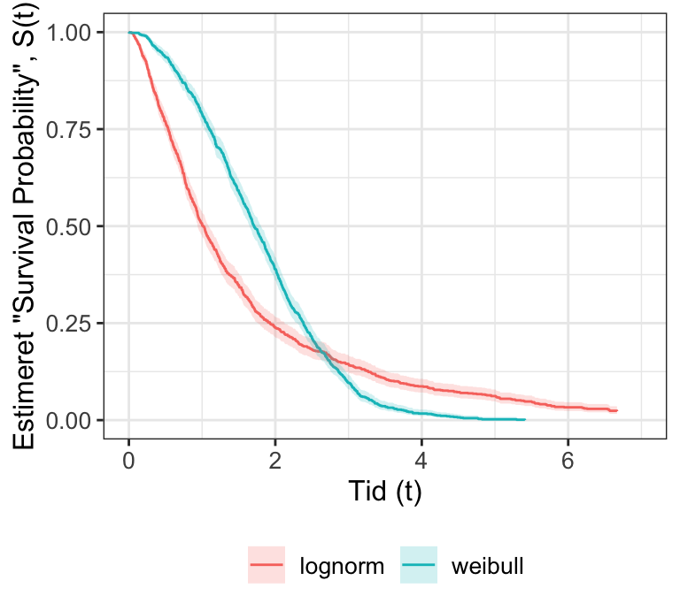

## Hvad kan vi ikke svare på med denne estimation af `S(t)` og `h(t)`?

- Den estimerede **pdf**, eller $f(t)$, fortæller også ikke noget om hvordan $S(t)$ og $h(t)$ er påvirket af `uafhængige variable`.
  - `Fixed` eller `time-varying`.

## Censurering (1)

Vi går mere i dybden til næste forelæsning, men grundlæggende handler det om hvor længe vi kan fælge enheder indenfor vores **datavindue**.

## Censurering (2)

### Kode

```r
data("lifelines_sample")
lexis_diagram <- lexis.grid(year.start = 1895,
                            year.end = 1905,
                            age.start = 0,
                            age.end = 10)
lexis.lifeline(lg = lexis_diagram,
               entry = lifelines_sample$entry,
               exit = lifelines_sample$exit,
               lineends = TRUE, alpha = 0.3)
```

### Output

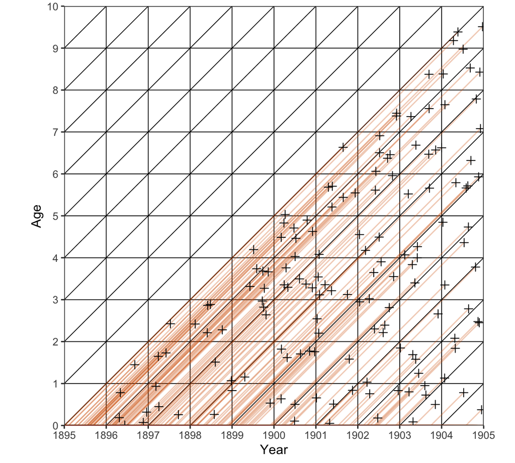

## Censurering (3): nyt datavindue

### Kode

```r
data("lifelines_sample")
lexis_diagram <- lexis.grid(year.start = 1900,
                            year.end = 1903,
                            age.start = 0,
                            age.end = 5)
lexis.lifeline(lg = lexis_diagram,
               entry = lifelines_sample$entry,
               exit = lifelines_sample$exit,
               lineends = TRUE, alpha = 0.3)
```

### Output

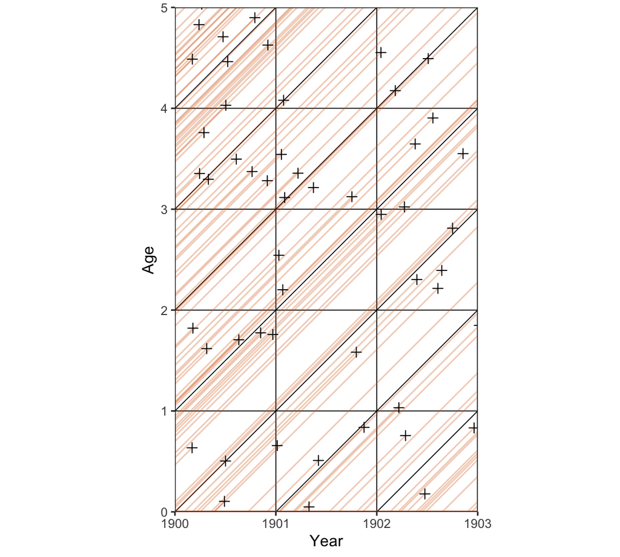

## Censurering (4)

### Analysen

- De røde linjer i Lexis Diagrammet repræsenterer de (livs)`forløb`, der er fokus for overlevelsesanalysen.
- `+` er de **observerede begivenheden** indenfor datavinduet.
- De forløb der fortsætter efter 1903 er højre-`censureret`, hvilket vil sige at vi ikke ved om/hvornår begivenheden indtræffer.
- De linjer der er påbegyndt før 1900 er `trunkerede`. Vi ved ikke om/hvor længe enheder har været i risiko før “år 0” eller oplevelde en relevant hændelse før “år 0”.

### Output

[figure not shown]

## Censurering (5): analyse

### Kode

```r
library(ggsurvfit)

df <-
  lifelines_sample %>%
  mutate(event = if_else(is.na(exit), 0, 1),
         exit = if_else(is.na(exit), as.Date("1905-01-01"), exit),
         tid = interval(ymd(entry), ymd(exit)) %/% days(1),
         aar_start = year(entry),
         aar_slut = year(exit),
         censureret = if_else(aar_slut >= 1903 & aar_start <= 1900, 0, 1))

survfit2(Surv(tid, event) ~ 1,
         data = df %>% filter(aar_slut >= 1903 & aar_start <= 1900)) %>%
  ggsurvfit() +
  labs(
    x = "Dage",
    y = expression(italic(hat("S")(t)))
  ) +
  add_confidence_interval() +
  scale_ggsurvfit() +
  add_censor_mark() +
  add_risktable(risktable_stats = c("n.risk", "cum.event", "n.censor")) +
  theme_minimal()
```

### Output

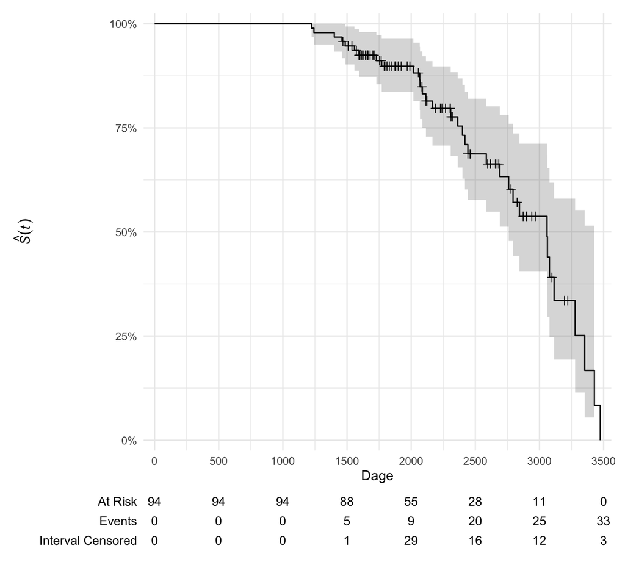

# Dagens øvelse

## Data og opgave

- *I skal bestemme tiden for fraflytning fra hjemmet efter påbegyndelse af videregående uddannelse*.
- Beskriv datasættet.
  - Hvor mange variable og observationer er der. Hvad viser de?
  - Skab et overblik over begivenheder over tid (e.g., barplots som vist i slides).
- Udregn $\hat S(t)$ med en Kaplan-Meier estimation, hvor i kun fokuserer på **tid** og **event** (ingen stratificering).
  - Udover $\hat S(t)$ skal i også plotte $F(t)$.
- Dataen i skal anvende er **flytte**`.csv` (download fra Moodle).
  - `df <- read_csv(here::here("flytte.csv"))`
  - `nr`: observations ID.
  - `dur`: tid til begivenhed eller censurering.
  - `status`: begivenhedsindikator (1/0).
  - `aargang` og `udd` arbejder vi med under forelæsningen næste gang.
- *Reflekter* over hvad censurering–og mangel på fokus herpå–kan betyde for jeres resultater.

Jeppe F. Qvist | 14. februar 2025